```python
import numpy as np
import matplotlib
import matplotlib.pyplot as plt
import scipy
from scipy import stats
import math
import statistics
import random
import pandas as pd


#this sets the size of the plot to something useful
plt.rcParams["figure.figsize"] = (15,10)
```

# Homework 5

The purpose of this homework is to work carefully through a numeric/simulted solution to Bayes' Theorem.

## Problem 1

First start by throwing a signal-free background. For Problem 1 choose a Normal distribution with some modest σ , say in the range 2-5. Create a million background events.

We choose our $\sigma$ to be 3

```python
x = list(range(1000000))
sigma = 3
background = stats.norm.rvs(loc=0, scale=sigma, size=1000000)
```

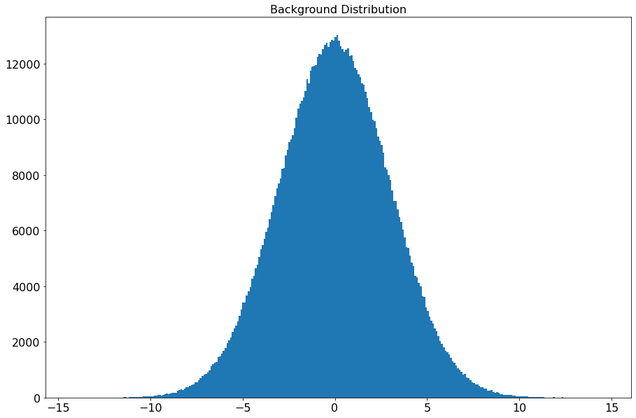

```python
plt.hist(background, bins = 300)
plt.title('Background Distribution', fontsize = 16)
plt.tick_params(labelsize = 16)
plt.show()
```

Now we need to make some signal. Let us choose to make signals of random strength on the interval of 0-20.

```python
signal = np.random.uniform(low=0.0, high=20, size=(1000000))
```

Now add your signal to your background to create fake data readings. Since you know what the true signal was for each data reading, and you used a flat prior, you now have P(data|signal)P(signal) .

```python
data = background + signal
```

Now make one of the 2D histograms as shown in class. Here we want to histogram the signal vs. the simulated data readings

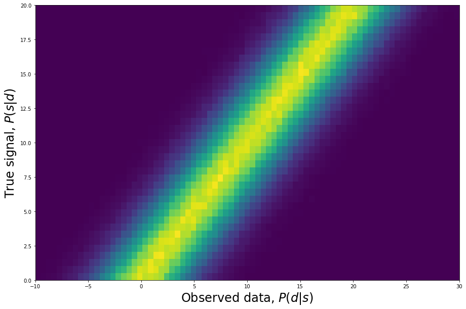

```python
signaledges = np.linspace(0,20,40)
dataedges = np.linspace(-10,30,80)

Psd, temp, temp2= np.histogram2d(data,signal, bins=[dataedges,signaledges], density=True)

datacenters = (dataedges[:-1] + dataedges[1:]) / 2
signalcenters = (signaledges[:-1] + signaledges[1:]) / 2
plt.pcolormesh(datacenters,signalcenters,Psd.T,shading='auto')
plt.ylabel('True signal, $P(s|d)$', fontsize = 24)
plt.xlabel('Observed data, $P(d|s)$', fontsize = 24)
plt.show()
```

Now to explore this we can take slices of the above. We can look at our array edges and pick a vertical or horizontal stripe.

### Problem 1b

Select a true injected signal and plot P(d|s) . (Use a stair style plot). Label your plot and clearly explain what you are plotting and how to interpret it.

In this case, we choose our true injected signal value to be 10. We are plotting a horizontal slice of the 2D histogram that corresponds to a true injected signal value of 10.

```python
my_data = pd.DataFrame(Psd)
```

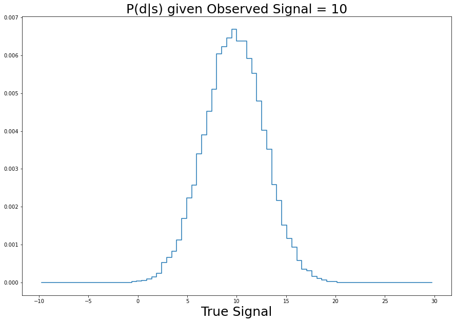

```python
slice = my_data.iloc[:,19]
plt.step(datacenters,slice);
plt.title('P(d|s) given Observed Signal = 10', fontsize=25);
plt.xlabel('True Signal', fontsize=25);
```

The plot gives us P(d|s): The probability distribution of the value of data in the presence of known (fake) signals(which is 10 in this specific case). It looks like a Gaussian distribution centered at 10.

### Problem 1b

Select an observed data value and plot P(s|d) . (Use a stair style plot). Label your plot and clearly explain what you are plotting and how to interpret it.

In this case, we will be plotting a vertical slice of the 2D histogram that corresponds to a observed data = 10.

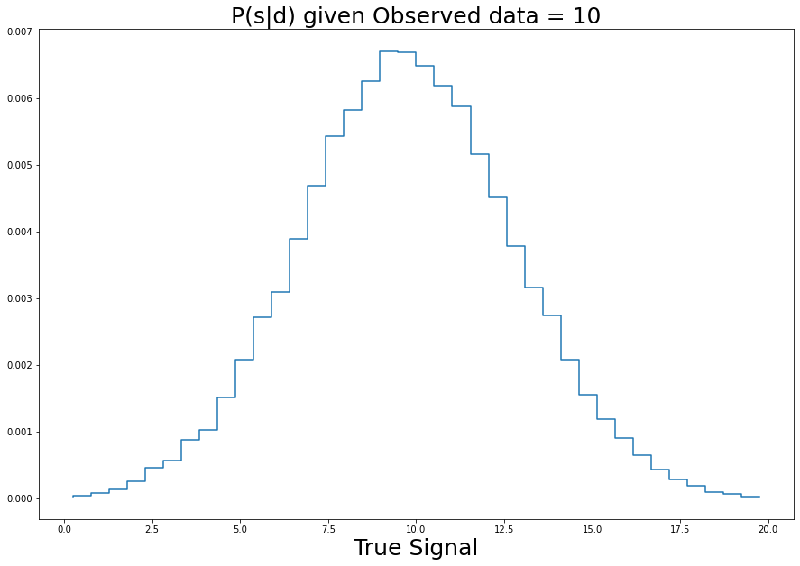

```python
slice = my_data.iloc[39,:]
plt.step(signalcenters,slice);
plt.title('P(s|d) given Observed data = 10', fontsize=25);
plt.xlabel('True Signal', fontsize=25);
```

The plot gives us P(s|d): The probability distribution of the value of signals in the presence of known observed data(which is 10 in this specific case). It looks like a Gaussian distribution centered at 10 as well.

## Problem 2

Now repeat the above, but with a background with non-zero mean. The easiest way would be to still have Guassian distribution but with a non-zero mean. [Hint: move it by at least a couple of σ ]. Reproduce the graphs above. Lastly overplot the P(d|s) and P(s|d) plots. Why are they not centered on the same value? Explain carefully.

We choose our new mean to be 5.

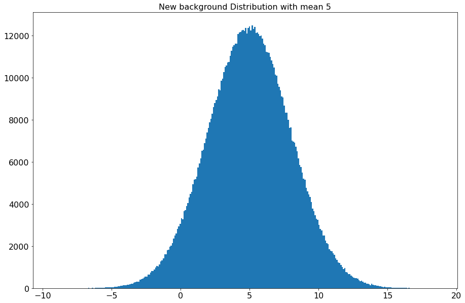

```python
background = stats.norm.rvs(loc=5, scale=sigma, size=1000000)
plt.hist(background, bins = 300)
plt.title('New background Distribution with mean 5', fontsize = 16)
plt.tick_params(labelsize = 16)
plt.show()
```

```python
data = background + signal
```

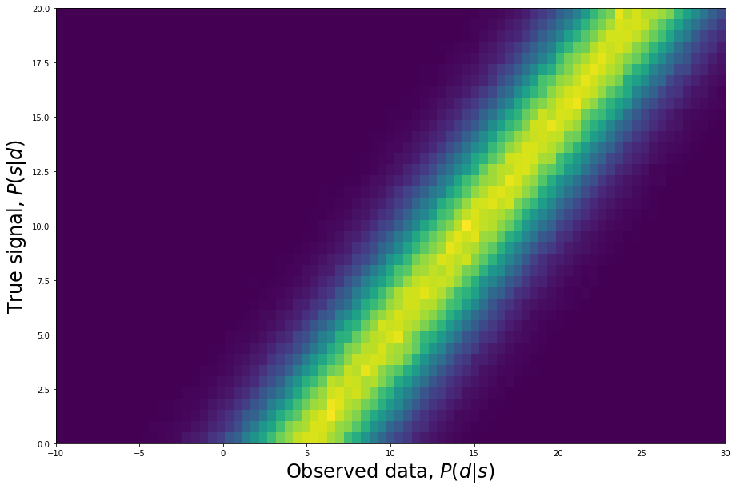

```python
signaledges = np.linspace(0,20,40)
dataedges = np.linspace(-10,30,80)

Psd, temp, temp2= np.histogram2d(data,signal, bins=[dataedges,signaledges], density=True)

datacenters = (dataedges[:-1] + dataedges[1:]) / 2
signalcenters = (signaledges[:-1] + signaledges[1:]) / 2
plt.pcolormesh(datacenters,signalcenters,Psd.T,shading='auto')
plt.ylabel('True signal, $P(s|d)$', fontsize = 24)
plt.xlabel('Observed data, $P(d|s)$', fontsize = 24)
plt.show()
```

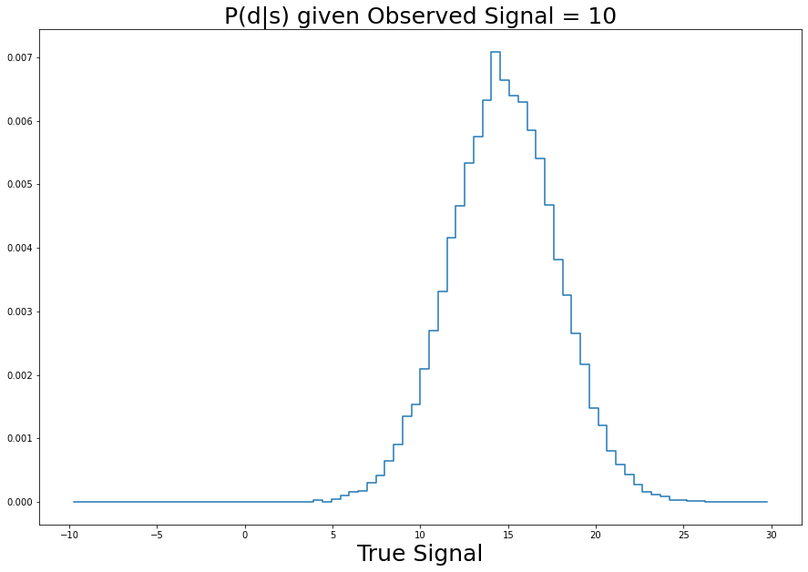

```python
my_data = pd.DataFrame(Psd)
slice1 = my_data.iloc[:,19]
plt.step(datacenters,slice1);
plt.title('P(d|s) given Observed Signal = 10', fontsize=25);
plt.xlabel('True Signal', fontsize=25);
```

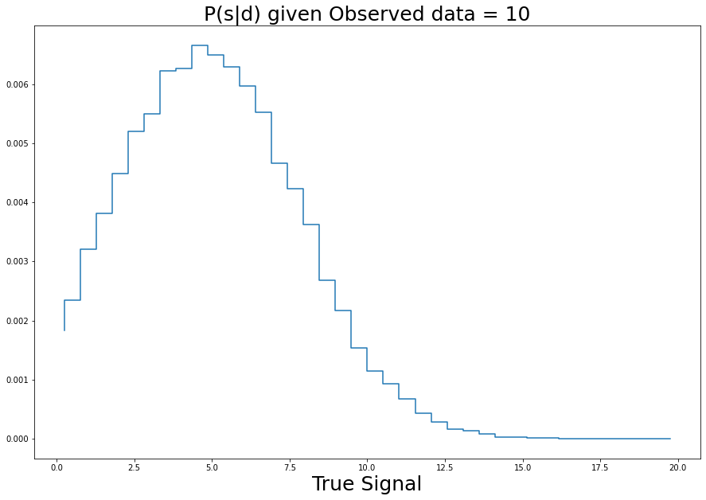

```python
slice2 = my_data.iloc[39,:]
plt.step(signalcenters,slice2);
plt.title('P(s|d) given Observed data = 10', fontsize=25);
plt.xlabel('True Signal', fontsize=25);
```

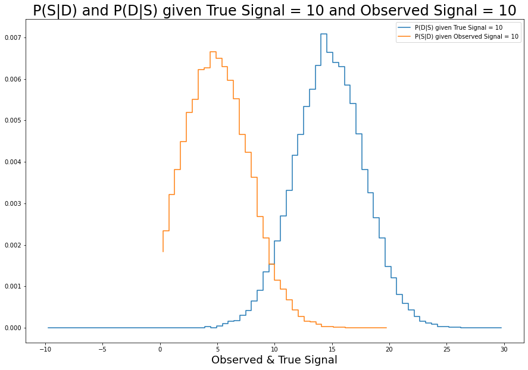

```python
plt.step(datacenters,slice1, label='P(D|S) given True Signal = 10');
plt.step(signalcenters,slice2, label='P(S|D) given Observed Signal = 10');
plt.legend()
plt.title('P(S|D) and P(D|S) given True Signal = 10 and Observed Signal = 10', fontsize=24)
plt.xlabel('Observed & True Signal', fontsize=18)
plt.show()
```

We can see that the two plots do not have the same mean value, with one of them being 5 and another one being 15. The reason behind this is, from the 2d histogram, we can see the whole arrangement is shifted by 5 to the right due to the mean of 5 of the background. THe shift makes a difference for both P(S|D) and P(D|S) with respect to the previous distributions.